# Assignment 4

Ken Gilliland, Kate Culhane, Sean Denny

November 13, 2018

### Part 1. Lobster abundance and fishing pressure (2012 - 2017)

**Ken:** Best way to depict these data? 1. Table of summary statistics for abundance and fishing data at each site 2. Figures of abundance at each site and fishing pressure (5 column graphs with abundance = column, and lines for fishing pressure)

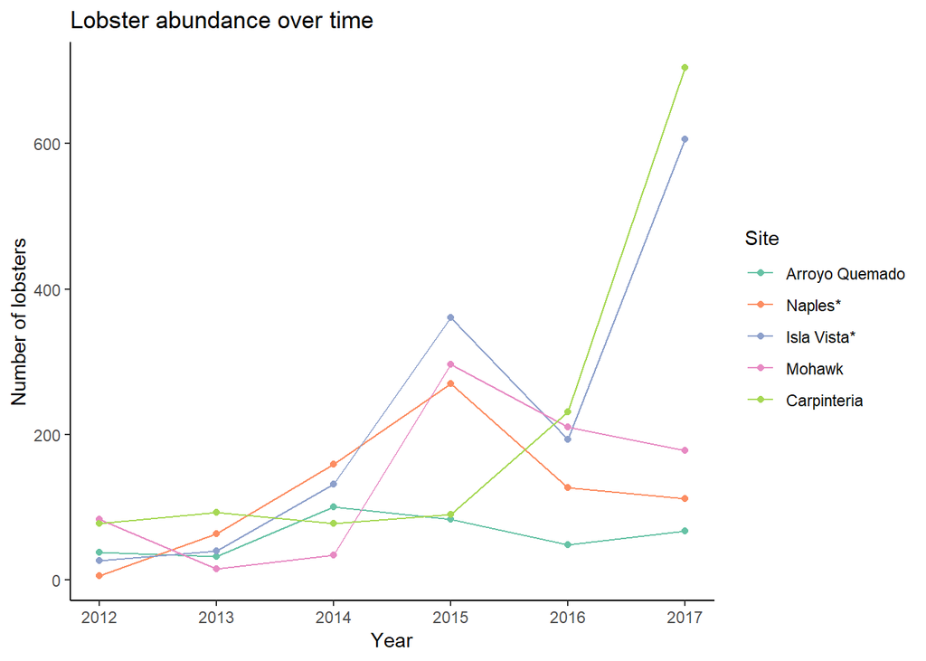

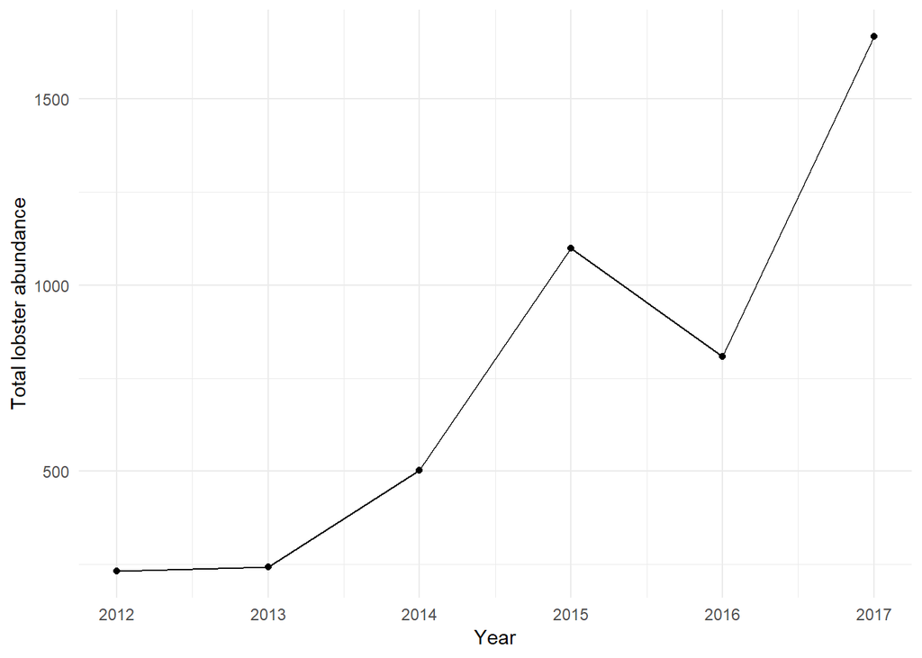

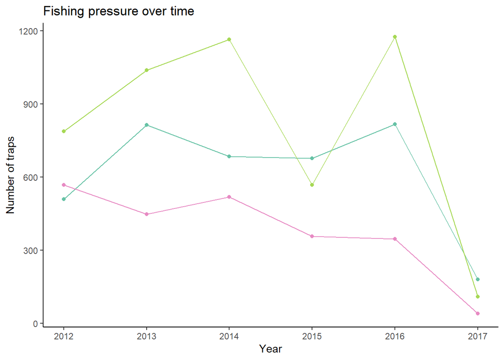

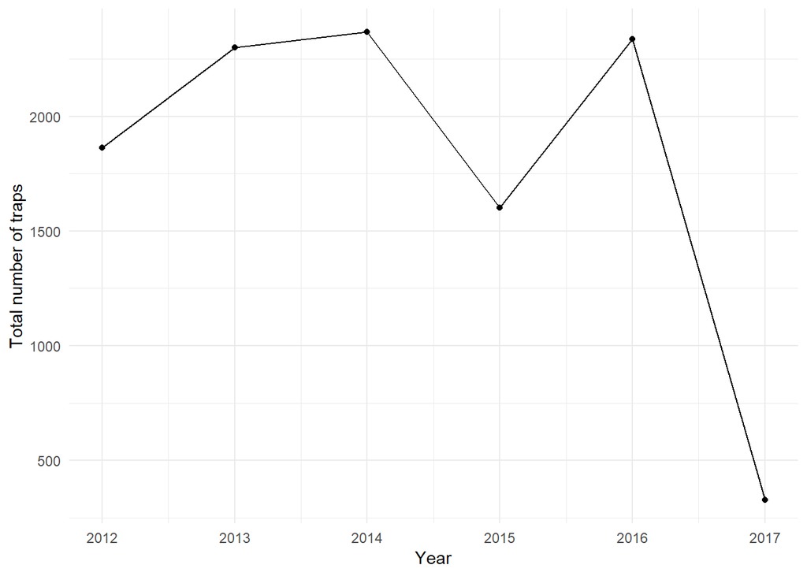

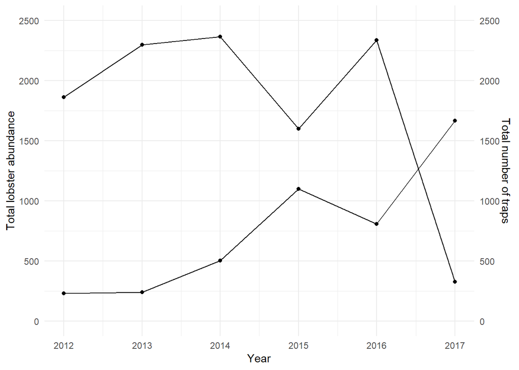

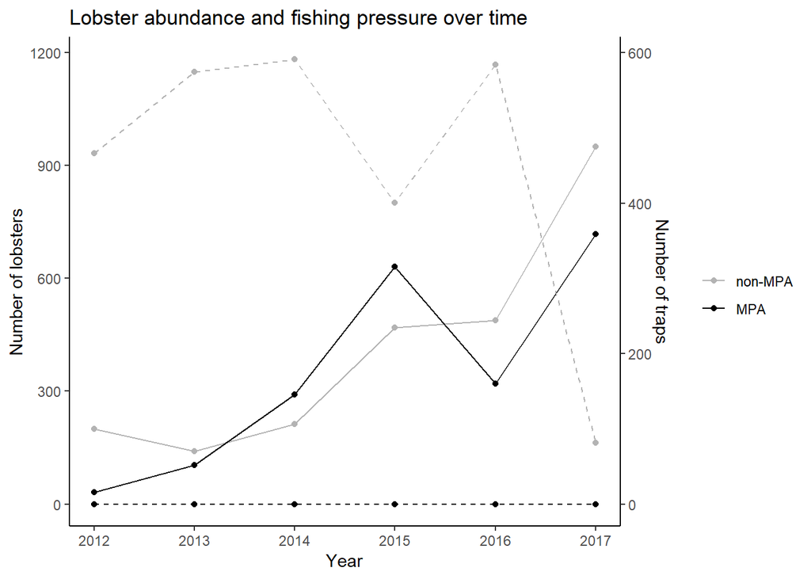

### Part 2. Mean lobster size by site in 2017

**Table 1.** **California spiny lobster (*Panulirus interruptus*) Carapace Length (mm) Recorded at five sites in the Santa Barbara Channel (2017).** Mean, standard deviation, and sample size of Carapace Length (mm) Recorded at five sites in the Santa Barbara Channel in 2017. Data retrieved from The Santa Barbara Coastal Long Term Ecological Research Project.

| Site | Mean | SD | n |
| --- | --- | --- | --- |
| Arroyo Quemado | 73.90 | 11.89 | 67 |
| Naples | 76.23 | 11.39 | 112 |
| Isla Vista | 71.45 | 14.32 | 606 |
| Mohawk | 72.00 | 9.28 | 178 |
| Carpinteria | 72.23 | 13.21 | 705 |

Satisfy the conditions of parametric tests (normal distribution, equal variance), so used ANOVA and Tukey’s HSD. Only found significantdifferences between:

1. NAPL and CARP
2. NAPL and IVEE

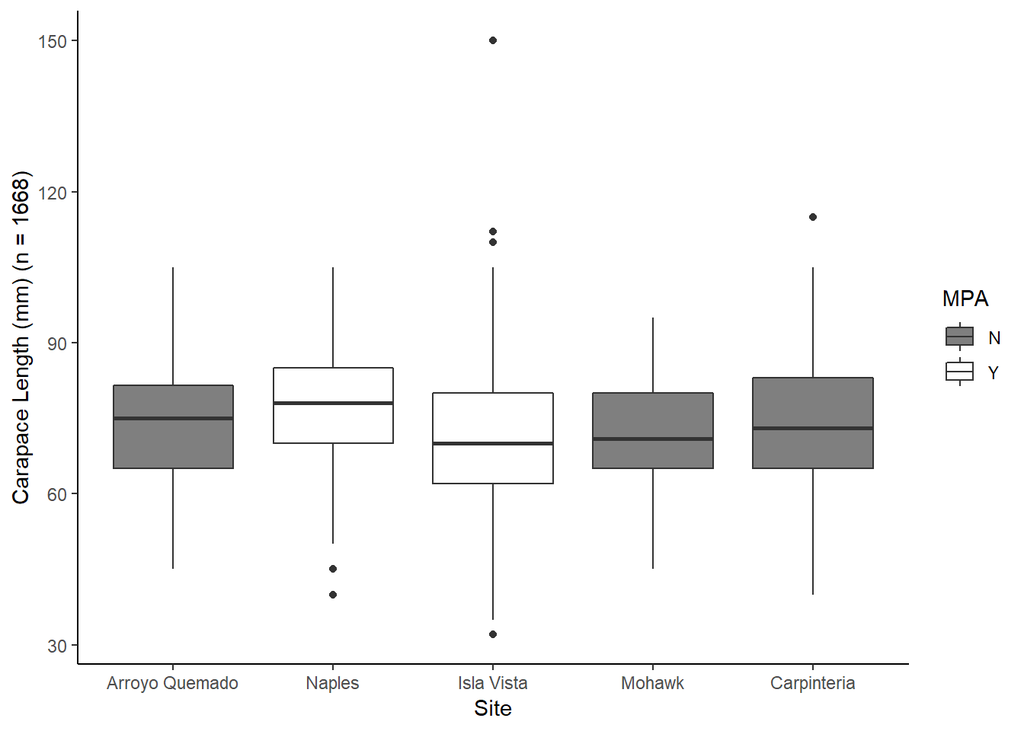

### Part 3. Changes in lobster size at MPA and non-MPA sites for 2012 and 2017

Variances were equal, so used student’s t-test to compare 2012 and 2017 and Cohen’s d to calculate effect size. Results:

**MPAs:** NO significant change in sizes from 2012 to 2017.

**non-MPAs:** significant change change in sizes from 2012 to 2017

- effect size is small
- actual difference: 2012 = 74.92, 2017 = 72.3

### Part 4. Proportions of “legal” lobsters at the 5 sites in 2017

```
## # A tibble: 5 x 6
##   site      N     Y     n propN propY
##   <chr> <int> <int> <int> <dbl> <dbl>
## 1 AQUE     51    16    67 0.761 0.239
## 2 NAPL     75    37   112 0.670 0.330
## 3 IVEE    476   130   606 0.785 0.215
## 4 MOHK    154    24   178 0.865 0.135
## 5 CARP    526   179   705 0.746 0.254
```

Ran chi-square on site vs. size and found a significant difference.